# Classification Problem – Stocks

Investigating LDA, QDA, Logistic Regression and KNN on stock data.

Sean Ammirati

October 11, 2016

```r
library(ISLR)
library(MASS)
library(class)
attach(Weekly)
dim(Weekly)
```

```
## [1] 1089    9
```

```r
summary(Weekly)
```

```
##       Year           Lag1               Lag2               Lag3
##  Min.   :1990   Min.   :-18.1950   Min.   :-18.1950   Min.   :-18.1950
##  1st Qu.:1995   1st Qu.: -1.1540   1st Qu.: -1.1540   1st Qu.: -1.1580
##  Median :2000   Median :  0.2410   Median :  0.2410   Median :  0.2410
##  Mean   :2000   Mean   :  0.1506   Mean   :  0.1511   Mean   :  0.1472
##  3rd Qu.:2005   3rd Qu.:  1.4050   3rd Qu.:  1.4090   3rd Qu.:  1.4090
##  Max.   :2010   Max.   : 12.0260   Max.   : 12.0260   Max.   : 12.0260
##       Lag4               Lag5              Volume
##  Min.   :-18.1950   Min.   :-18.1950   Min.   :0.08747
##  1st Qu.: -1.1580   1st Qu.: -1.1660   1st Qu.:0.33202
##  Median :  0.2380   Median :  0.2340   Median :1.00268
##  Mean   :  0.1458   Mean   :  0.1399   Mean   :1.57462
##  3rd Qu.:  1.4090   3rd Qu.:  1.4050   3rd Qu.:2.05373
##  Max.   : 12.0260   Max.   : 12.0260   Max.   :9.32821
##      Today          Direction
##  Min.   :-18.1950   Down:484
##  1st Qu.: -1.1540   Up  :605
##  Median :  0.2410
##  Mean   :  0.1499
##  3rd Qu.:  1.4050
##  Max.   : 12.0260
```

```r
cor(Weekly[,-9])
```

```
##               Year         Lag1        Lag2        Lag3         Lag4
## Year    1.00000000 -0.032289274 -0.03339001 -0.03000649 -0.031127923
## Lag1   -0.03228927  1.000000000 -0.07485305  0.05863568 -0.071273876
## Lag2   -0.03339001 -0.074853051  1.00000000 -0.07572091  0.058381535
## Lag3   -0.03000649  0.058635682 -0.07572091  1.00000000 -0.075395865
## Lag4   -0.03112792 -0.071273876  0.05838153 -0.07539587  1.000000000
## Lag5   -0.03051910 -0.008183096 -0.07249948  0.06065717 -0.075675027
## Volume  0.84194162 -0.064951313 -0.08551314 -0.06928771 -0.061074617
## Today  -0.03245989 -0.075031842  0.05916672 -0.07124364 -0.007825873
##                Lag5      Volume        Today
## Year   -0.030519101  0.84194162 -0.032459894
## Lag1   -0.008183096 -0.06495131 -0.075031842
## Lag2   -0.072499482 -0.08551314  0.059166717
## Lag3    0.060657175 -0.06928771 -0.071243639
## Lag4   -0.075675027 -0.06107462 -0.007825873
## Lag5    1.000000000 -0.05851741  0.011012698
## Volume -0.058517414  1.00000000 -0.033077783
## Today   0.011012698 -0.03307778  1.000000000
```

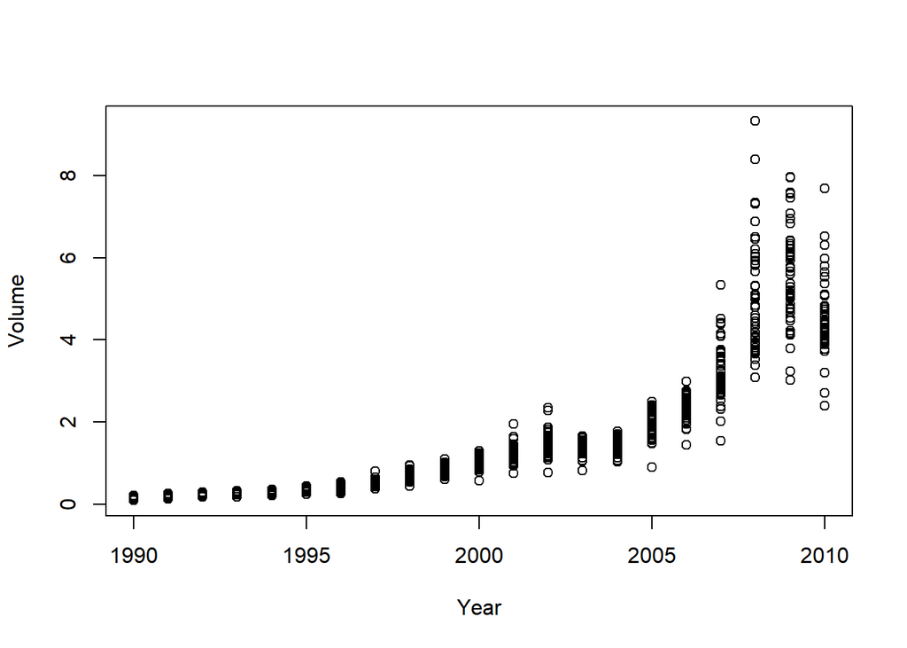

```r
plot(Year,Volume)
```

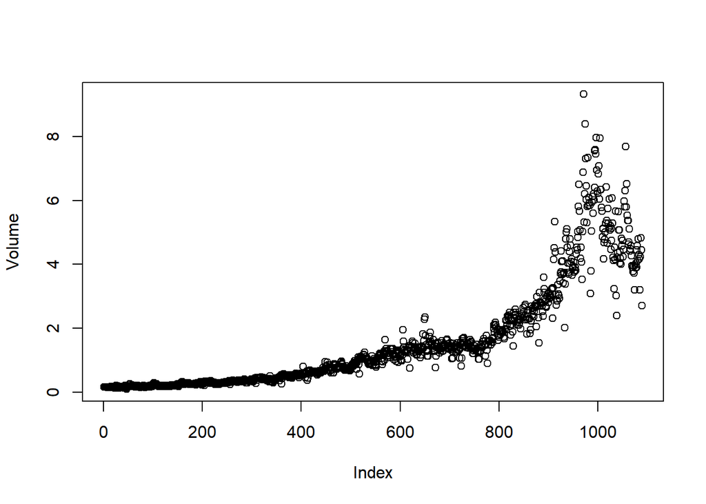

```r
plot(Volume)
```

It appears that the Lag variables are only very slightly uncorrelated (with cor close to 0). Only Year and Volume seem to have a direct correlation. Plotting Volume against Year confirms this, as there seems to be an upward trend.

```r
glm.fit <- glm(Direction ~ Lag1 + Lag2 + Lag3 + Lag4 + Lag5 + Volume, family = binomial,data = Weekly)
summary(glm.fit)
```

```
##
## Call:
## glm(formula = Direction ~ Lag1 + Lag2 + Lag3 + Lag4 + Lag5 +
##     Volume, family = binomial, data = Weekly)
##
## Deviance Residuals:
##     Min       1Q   Median       3Q      Max
## -1.6949  -1.2565   0.9913   1.0849   1.4579
##
## Coefficients:
##             Estimate Std. Error z value Pr(>|z|)
## (Intercept)  0.26686    0.08593   3.106   0.0019 **
## Lag1        -0.04127    0.02641  -1.563   0.1181
## Lag2         0.05844    0.02686   2.175   0.0296 *
## Lag3        -0.01606    0.02666  -0.602   0.5469
## Lag4        -0.02779    0.02646  -1.050   0.2937
## Lag5        -0.01447    0.02638  -0.549   0.5833
## Volume      -0.02274    0.03690  -0.616   0.5377
## ---
## Signif. codes:  0 '***' 0.001 '**' 0.01 '*' 0.05 '.' 0.1 ' ' 1
##
## (Dispersion parameter for binomial family taken to be 1)
##
##     Null deviance: 1496.2  on 1088  degrees of freedom
## Residual deviance: 1486.4  on 1082  degrees of freedom
## AIC: 1500.4
##
## Number of Fisher Scoring iterations: 4
```

```r
coef(glm.fit)
```

```
## (Intercept)        Lag1        Lag2        Lag3        Lag4        Lag5
##  0.26686414 -0.04126894  0.05844168 -0.01606114 -0.02779021 -0.01447206
##      Volume
## -0.02274153
```

```r
summary(glm.fit)$coef
```

```
##                Estimate Std. Error    z value    Pr(>|z|)
## (Intercept)  0.26686414 0.08592961  3.1056134 0.001898848
## Lag1        -0.04126894 0.02641026 -1.5626099 0.118144368
## Lag2         0.05844168 0.02686499  2.1753839 0.029601361
## Lag3        -0.01606114 0.02666299 -0.6023760 0.546923890
## Lag4        -0.02779021 0.02646332 -1.0501409 0.293653342
## Lag5        -0.01447206 0.02638478 -0.5485006 0.583348244
## Volume      -0.02274153 0.03689812 -0.6163330 0.537674762
```

AS we can see from the summary of the coefficients, only Lag2 seems to be significant at the 5% level.

```r
glm.probs <- predict(glm.fit,type = "response")
glm.pred <- rep("Down",1089)
glm.pred[glm.probs > .5] <- "Up"
glm.pred
```

[output not shown]

[output cut: 106 more lines]

```r
confusionmatrix <- table(glm.pred,Direction)
confusionmatrix
```

```
##         Direction
## glm.pred Down  Up
##     Down   54  48
##     Up    430 557
```

```r
mean(glm.pred == Direction)
```

```
## [1] 0.5610652
```

The confusion matrix is telling us that, on average, the model correctly predicts the training data 56.107% of the time. This means that the training error rate for the logistic regression is 44%. Of course, this is likely an underestimation since it is using the same data it was modeled with to predict. When the true direction is Up, the model is very accurate, with 92% of the data being predicted accurately. However, when the true direction is down, the model doesn’t fare well at all, with only 11% being reported accurately. That is, it tends to make much more mistakes when the true direction is down than when it is up.

```r
Boolean <- (Year < 2009)
WeeklyTraining <- Weekly[Boolean,]
WeeklyTest <- Weekly[!Boolean,]
Direction_Training <- Direction[Boolean]
Direction_Test <- Direction[!Boolean]
glm.fit2 <- glm(Direction ~ Lag2,family = binomial,data = Weekly,subset = Boolean)
summary(glm.fit2)
```

```
##
## Call:
## glm(formula = Direction ~ Lag2, family = binomial, data = Weekly,
##     subset = Boolean)
##
## Deviance Residuals:
##    Min      1Q  Median      3Q     Max
## -1.536  -1.264   1.021   1.091   1.368
##
## Coefficients:
##             Estimate Std. Error z value Pr(>|z|)
## (Intercept)  0.20326    0.06428   3.162  0.00157 **
## Lag2         0.05810    0.02870   2.024  0.04298 *
## ---
## Signif. codes:  0 '***' 0.001 '**' 0.01 '*' 0.05 '.' 0.1 ' ' 1
##
## (Dispersion parameter for binomial family taken to be 1)
##
##     Null deviance: 1354.7  on 984  degrees of freedom
## Residual deviance: 1350.5  on 983  degrees of freedom
## AIC: 1354.5
##
## Number of Fisher Scoring iterations: 4
```

```r
glm.probs2 <- predict(glm.fit2,WeeklyTest,type = "response")
glm.pred2 <- rep("Down",104)
glm.pred2[glm.probs2 >= .5] <- "Up"
table(glm.pred2,Direction_Test)
```

```
##          Direction_Test
## glm.pred2 Down Up
##      Down    9  5
##      Up     34 56
```

```r
mean(glm.pred2 == Direction_Test)
```

```
## [1] 0.625
```

```r
library(MASS)
lda.fit <- lda(Direction~Lag2,data = Weekly,subset = Boolean)
lda.fit
```

```
## Call:
## lda(Direction ~ Lag2, data = Weekly, subset = Boolean)
##
## Prior probabilities of groups:
##      Down        Up
## 0.4477157 0.5522843
##
## Group means:
##             Lag2
## Down -0.03568254
## Up    0.26036581
##
## Coefficients of linear discriminants:
##            LD1
## Lag2 0.4414162
```

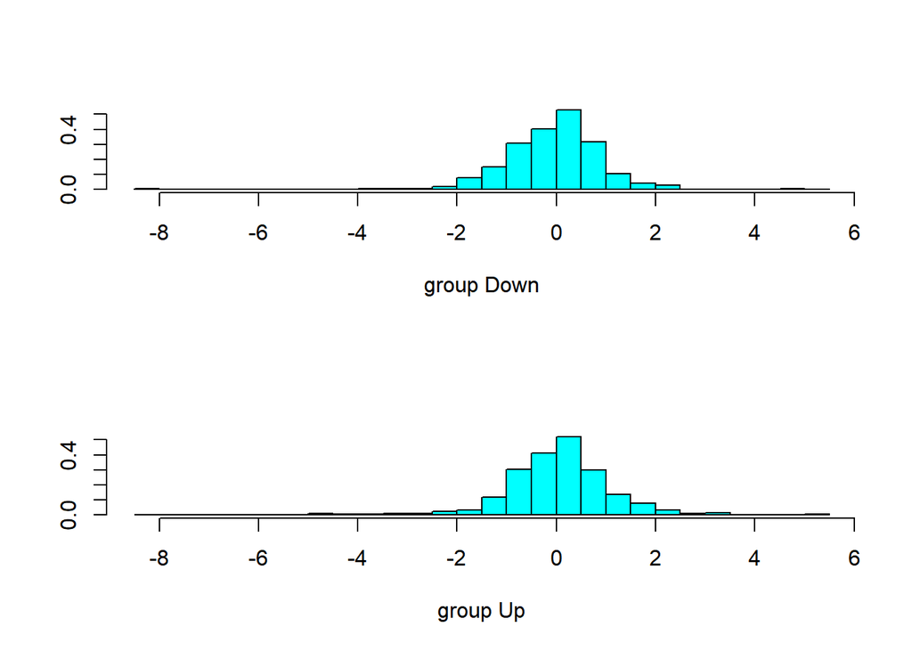

```r
plot(lda.fit)
```

```r
lda.predict <- predict(lda.fit,WeeklyTest,type = "response")
names(lda.predict)
```

```
## [1] "class"     "posterior" "x"
```

```r
lda.class <- lda.predict$class
table(lda.class,Direction_Test)
```

```
##          Direction_Test
## lda.class Down Up
##      Down    9  5
##      Up     34 56
```

```r
mean(lda.class == Direction_Test)
```

```
## [1] 0.625
```

```r
qda.fit <- qda(Direction ~ Lag2,data = Weekly,subset = Boolean)
qda.predict <- predict(qda.fit,WeeklyTest)$class
table(qda.predict,Direction_Test)
```

```
##            Direction_Test
## qda.predict Down Up
##        Down    0  0
##        Up     43 61
```

```r
mean(qda.predict == Direction_Test)
```

```
## [1] 0.5865385
```

The qda predicts all ups!

```r
train <- as.matrix(Lag2[Boolean])
test <- as.matrix(Lag2[!Boolean])
knn.predict <- knn(train,test,Direction_Training,1)
table(knn.predict,Direction_Test)
```

```
##            Direction_Test
## knn.predict Down Up
##        Down   21 29
##        Up     22 32
```

```r
mean(knn.predict == Direction_Test)
```

```
## [1] 0.5096154
```

# Logistic Regression Prediction

```r
table(glm.pred2,Direction_Test)
```

```
##          Direction_Test
## glm.pred2 Down Up
##      Down    9  5
##      Up     34 56
```

```r
mean(glm.pred2 == Direction_Test)
```

```
## [1] 0.625
```

# Linear Discriminant Prediction

```r
table(lda.class,Direction_Test)
```

```
##          Direction_Test
## lda.class Down Up
##      Down    9  5
##      Up     34 56
```

```r
mean(lda.class == Direction_Test)
```

```
## [1] 0.625
```

# Quadratic Discriminant Prediction

```r
table(qda.predict,Direction_Test)
```

```
##            Direction_Test
## qda.predict Down Up
##        Down    0  0
##        Up     43 61
```

```r
mean(qda.predict == Direction_Test)
```

```
## [1] 0.5865385
```

# K-Nearest Neighbors Prediction

```r
table(knn.predict,Direction_Test)
```

```
##            Direction_Test
## knn.predict Down Up
##        Down   21 29
##        Up     22 32
```

```r
mean(knn.predict == Direction_Test)
```

```
## [1] 0.5096154
```

It appears that either the logistic regression or the LDA method is the most accurate, with both of their mean values with the test data being .625. This is fairly good – it means that using the models, we can correctly guess whether the direction will go up or down with more than a 50-50 chance. A 100-62.5=37.5% error rate is not bad at all when considering stock data. Would I bet for it? I would need more data to really say, but if this were the case with any test data set, using the model could clearly be very profitable. If only things were so simple!

```r
summary(glm.fit)
```

```
##
## Call:
## glm(formula = Direction ~ Lag1 + Lag2 + Lag3 + Lag4 + Lag5 +
##     Volume, family = binomial, data = Weekly)
##
## Deviance Residuals:
##     Min       1Q   Median       3Q      Max
## -1.6949  -1.2565   0.9913   1.0849   1.4579
##
## Coefficients:
##             Estimate Std. Error z value Pr(>|z|)
## (Intercept)  0.26686    0.08593   3.106   0.0019 **
## Lag1        -0.04127    0.02641  -1.563   0.1181
## Lag2         0.05844    0.02686   2.175   0.0296 *
## Lag3        -0.01606    0.02666  -0.602   0.5469
## Lag4        -0.02779    0.02646  -1.050   0.2937
## Lag5        -0.01447    0.02638  -0.549   0.5833
## Volume      -0.02274    0.03690  -0.616   0.5377
## ---
## Signif. codes:  0 '***' 0.001 '**' 0.01 '*' 0.05 '.' 0.1 ' ' 1
##
## (Dispersion parameter for binomial family taken to be 1)
##
##     Null deviance: 1496.2  on 1088  degrees of freedom
## Residual deviance: 1486.4  on 1082  degrees of freedom
## AIC: 1500.4
##
## Number of Fisher Scoring iterations: 4
```

Since Lag1 was the runner-up in this case for significance, let’s do a model containing both Lag1 and Lag2.

```r
glm.fit3 <- glm(Direction ~ Lag1 + Lag2,family = binomial,data = Weekly,subset = Boolean)
summary(glm.fit3)
```

```
##
## Call:
## glm(formula = Direction ~ Lag1 + Lag2, family = binomial, data = Weekly,
##     subset = Boolean)
##
## Deviance Residuals:
##     Min       1Q   Median       3Q      Max
## -1.6149  -1.2565   0.9989   1.0875   1.5330
##
## Coefficients:
##             Estimate Std. Error z value Pr(>|z|)
## (Intercept)  0.21109    0.06456   3.269  0.00108 **
## Lag1        -0.05421    0.02886  -1.878  0.06034 .
## Lag2         0.05384    0.02905   1.854  0.06379 .
## ---
## Signif. codes:  0 '***' 0.001 '**' 0.01 '*' 0.05 '.' 0.1 ' ' 1
##
## (Dispersion parameter for binomial family taken to be 1)
##
##     Null deviance: 1354.7  on 984  degrees of freedom
## Residual deviance: 1347.0  on 982  degrees of freedom
## AIC: 1353
##
## Number of Fisher Scoring iterations: 4
```

```r
glm.probs3 <- predict(glm.fit3,WeeklyTest,type = "response")
glm.predict <- rep("Down",104)
glm.predict[glm.probs3 > .5] <- "Up"
table(glm.predict,Direction_Test)
```

```
##            Direction_Test
## glm.predict Down Up
##        Down    7  8
##        Up     36 53
```

```r
mean(glm.predict == Direction_Test)
```

```
## [1] 0.5769231
```

This is still not as accurate as the model with just Lag2 in it.

Let’s try the K-Nearest Neighbors with K=5

```r
knn.predict2 <- knn(train,test,Direction_Training,5)
table(knn.predict2,Direction_Test)
```

```
##             Direction_Test
## knn.predict2 Down Up
##         Down   15 20
##         Up     28 41
```

```r
mean(knn.predict2 == Direction_Test)
```

```
## [1] 0.5384615
```

```r
mean(knn.predict == Direction_Test)
```

```
## [1] 0.5096154
```

So, it appears it was more accurate than with only 1 neighbor. Let’s try with k=21

```r
knn.predict3 <- knn(train,test,Direction_Training,21)
mean(knn.predict3 == Direction_Test)
```

```
## [1] 0.5480769
```

```r
knn.predict4 <- knn(train,test,Direction_Training,41)
mean(knn.predict4 == Direction_Test)
```

```
## [1] 0.5673077
```

Let’s try using different prior probabilities. Let’s say we really want our model to be accurate when the true direction is down, not up. That is, we want to be more conservative. Let’s say the probability of it being down is, .75. So…

```r
lda.fit2 <- lda(Direction ~ Lag2,data = Weekly,subset = Boolean,prior = c(.75,.25))
lda.predict2 <- predict(lda.fit2,WeeklyTest,type = "response")
table(lda.predict2$class,Direction_Test)
```

```
##       Direction_Test
##        Down Up
##   Down   43 61
##   Up      0  0
```

Clearly that prior was too high! We predict all downs. Let’s try with 52%.

```r
lda.fit3 <- lda(Direction ~ Lag2,data = Weekly,subset = Boolean,prior = c(.52,.48))
lda.predict3 <- predict(lda.fit3,WeeklyTest,type = "response")
table(lda.predict3$class,Direction_Test)
```

```
##       Direction_Test
##        Down Up
##   Down   28 39
##   Up     15 22
```

```r
mean(lda.predict3$class == Direction_Test)
```

```
## [1] 0.4807692
```

So, now our prediction rate is lower than .5, which is not very good. But at least in this case, when the true direction is down, we are more accurate at estimating it. While, now, when it is up, we are less accurate.

Finally, I will try a glm model with interaction terms.

```r
glm.fit4 <- glm(Direction ~ Volume + Lag2 + Volume*Lag2,data = Weekly,subset = Boolean,family = binomial)
summary(glm.fit4)
```

```
##
## Call:
## glm(formula = Direction ~ Volume + Lag2 + Volume * Lag2, family = binomial,
##     data = Weekly, subset = Boolean)
##
## Deviance Residuals:
##    Min      1Q  Median      3Q     Max
## -1.438  -1.263   1.022   1.086   1.521
##
## Coefficients:
##             Estimate Std. Error z value Pr(>|z|)
## (Intercept)  0.27007    0.09024   2.993  0.00277 **
## Volume      -0.05436    0.05279  -1.030  0.30317
## Lag2         0.05036    0.03998   1.260  0.20781
## Volume:Lag2  0.00151    0.01328   0.114  0.90945
## ---
## Signif. codes:  0 '***' 0.001 '**' 0.01 '*' 0.05 '.' 0.1 ' ' 1
##
## (Dispersion parameter for binomial family taken to be 1)
##
##     Null deviance: 1354.7  on 984  degrees of freedom
## Residual deviance: 1349.4  on 981  degrees of freedom
## AIC: 1357.4
##
## Number of Fisher Scoring iterations: 4
```

```r
glm.probs4 <- predict(glm.fit4,WeeklyTest,type = "response")
glm.predict4 <- rep("Down",104)
glm.predict4[glm.probs4 >= .5] <- "Up"
table(glm.predict4,Direction_Test)
```

```
##             Direction_Test
## glm.predict4 Down Up
##         Down   20 25
##         Up     23 36
```

```r
mean(glm.predict4 == Direction_Test)
```

```
## [1] 0.5384615
```

So, it seems that the results of the glm regression were the most accurate – Lag2 is truly the only significant factor as determined by the training data. Even though Volume had a tren, it doesn’t seem to have had much of an effect. Since it was quadratic, however…

```r
qda.fit2 <- qda(Direction ~ Lag2 + Volume + Volume^2,data = Weekly,subset = Boolean)
qda.predict2 <- predict(qda.fit2,WeeklyTest)$class
table(qda.predict2,Direction_Test)
```

```
##             Direction_Test
## qda.predict2 Down Up
##         Down   32 44
##         Up     11 17
```

```r
mean(qda.predict2 == Direction_Test)
```

```
## [1] 0.4711538
```

No. It was a long shot, but it doesn’t seem that the underlying distribution of the Volume really meant that using QDA would magically make it significant.